# Laboratorio 5

Erik De Luca

2022-11-17

Importo i dati e trasformo le variabili `Face` e `Income`.

```r
tl = read.csv("dataset/TL.csv") %>% tibble %>% select(-X)
tl = tl %>% mutate_at(c( "MARSTAT"), as.factor)
colLog = c("FACE","INCOME")
tl = tl %>% mutate_at(colLog,log) %>% rename_at(colLog, function(c) paste("L",c,sep = ""))
tl
```

| AGE | MARSTAT | EDUCATION | NUMHH | LINCOME | LFACE |
| --- | --- | --- | --- | --- | --- |
| 30 | not single | 16 | 3 | 10.668955 | 9.903488 |
| 50 | not single | 9 | 3 | 9.392662 | 11.775290 |
| 39 | not single | 16 | 5 | 11.695247 | 14.220976 |
| 43 | not single | 17 | 4 | 10.596635 | 10.819778 |
| 34 | not single | 11 | 4 | 10.239960 | 12.301383 |
| 29 | not single | 16 | 3 | 11.512925 | 13.304685 |
| 72 | not single | 17 | 2 | 11.626254 | 11.512925 |
| 51 | not single | 16 | 4 | 9.615805 | 14.731801 |
| 58 | single | 14 | 1 | 10.373491 | 12.429216 |
| 73 | not single | 12 | 2 | 10.126631 | 10.819778 |

[output cut: 265 more lines]

```r
set.seed(1)
train = createDataPartition(tl$AGE,p = .7,list = F)
```

## Albero

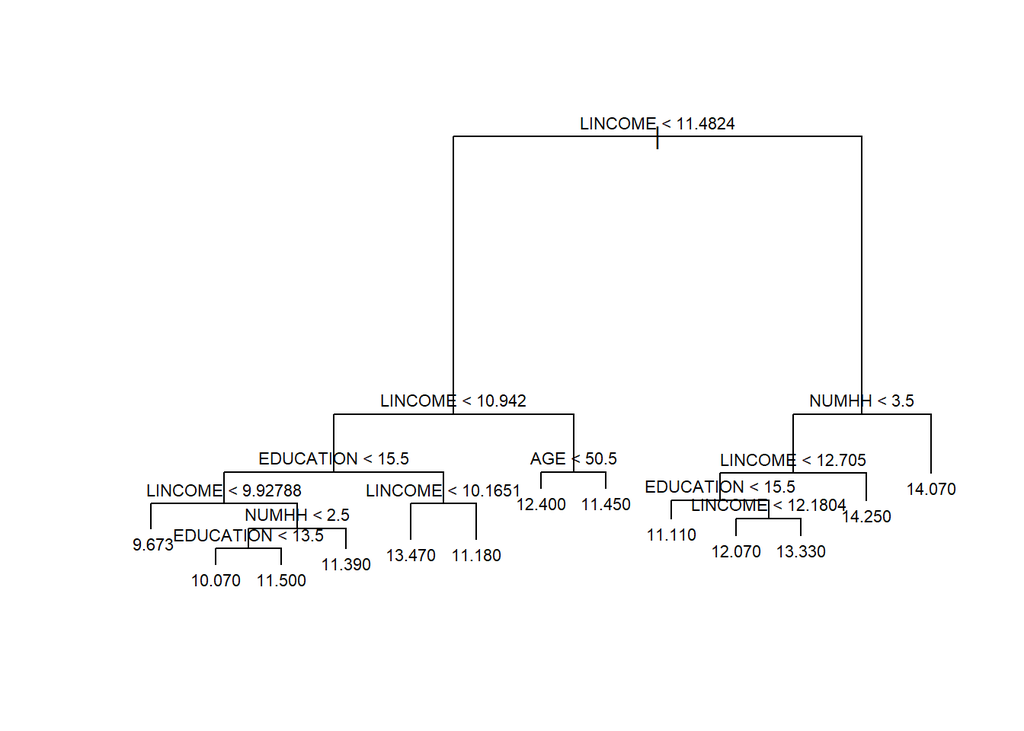

```r
albero = tree(LFACE ~ ., data = tl[train,])
{
  plot(albero)
  text(albero, cex = 0.7)
}
```

### Confronto l’albero con altri modelli

#### Regressione lineare multipla

Per scegliere il modello migliore di regressione lineare utilizzo il criterio dell’informazione di Akaike (AIC), che va penalizzare i modelli con troppe variabili e poche informazioni aggiuntive, come $R_{adj}^2$. Tramite la funzione `stepAIC` andiamo a selezionare il modello con il minore AIC.

```r
modLm = MASS::stepAIC(lm(LFACE ~ ., data = tl[train,]))
```

```
## Start:  AIC=140.03
## LFACE ~ AGE + MARSTAT + EDUCATION + NUMHH + LINCOME
##
##             Df Sum of Sq    RSS    AIC
## - MARSTAT    1     2.434 378.42 139.29
## - AGE        1     3.535 379.52 139.85
## <none>                   375.99 140.03
## - NUMHH      1    19.560 395.55 147.92
## - EDUCATION  1    27.044 403.03 151.57
## - LINCOME    1    77.135 453.12 174.42
##
## Step:  AIC=139.29
## LFACE ~ AGE + EDUCATION + NUMHH + LINCOME
##
##             Df Sum of Sq    RSS    AIC
## - AGE        1     2.847 381.27 138.75
## <none>                   378.42 139.29
## - EDUCATION  1    25.846 404.27 150.17
## - NUMHH      1    32.756 411.18 153.47
## - LINCOME    1    87.505 465.93 177.85
##
## Step:  AIC=138.75
## LFACE ~ EDUCATION + NUMHH + LINCOME
##
##             Df Sum of Sq    RSS    AIC
## <none>                   381.27 138.75
## - EDUCATION  1    25.671 406.94 149.46
## - NUMHH      1    42.432 423.70 157.33
## - LINCOME    1    84.659 465.93 175.85
```

```r
modLm %>% summary
```

```
##
## Call:
## lm(formula = LFACE ~ EDUCATION + NUMHH + LINCOME, data = tl[train,
##     ])
##
## Residuals:
##     Min      1Q  Median      3Q     Max
## -5.8398 -0.7949  0.1235  0.9196  5.2222
##
## Coefficients:
##             Estimate Std. Error t value Pr(>|t|)
## (Intercept)  1.43477    1.01113   1.419 0.157534
## EDUCATION    0.15547    0.04335   3.586 0.000426 ***
## NUMHH        0.32051    0.06952   4.611 7.34e-06 ***
## LINCOME      0.65302    0.10027   6.512 6.38e-10 ***
## ---
## Signif. codes:  0 '***' 0.001 '**' 0.01 '*' 0.05 '.' 0.1 ' ' 1
##
## Residual standard error: 1.413 on 191 degrees of freedom
## Multiple R-squared:  0.4035, Adjusted R-squared:  0.3941
## F-statistic: 43.06 on 3 and 191 DF,  p-value: < 2.2e-16
```

#### Lasso

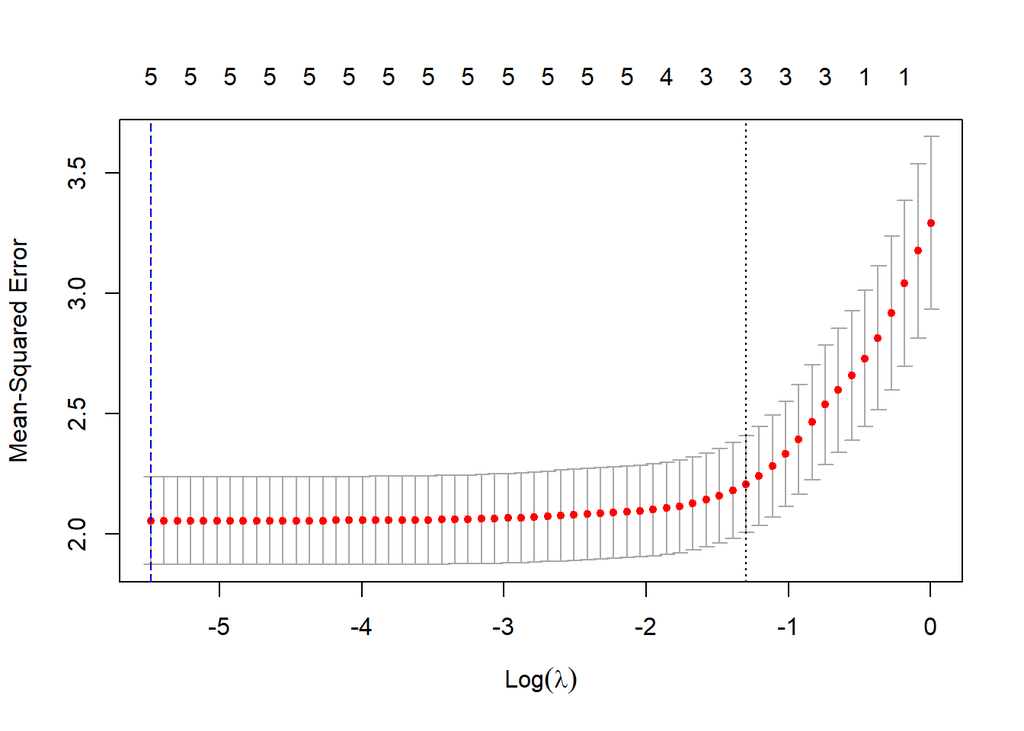

```r
modLasso = glmnet(x = makeX(tl[train,names(tl)!= "LFACE"]),
                  y = tl$LFACE[train],
                  alpha = 1)
cvModLasso = cv.glmnet(makeX(tl[train,names(tl)!= "LFACE"]),
                       tl$LFACE[train],
                       alpha = 1)
{
  plot(cvModLasso)
  abline(v = log(cvModLasso$lambda.min), col = "blue", lty = 2)
}
```

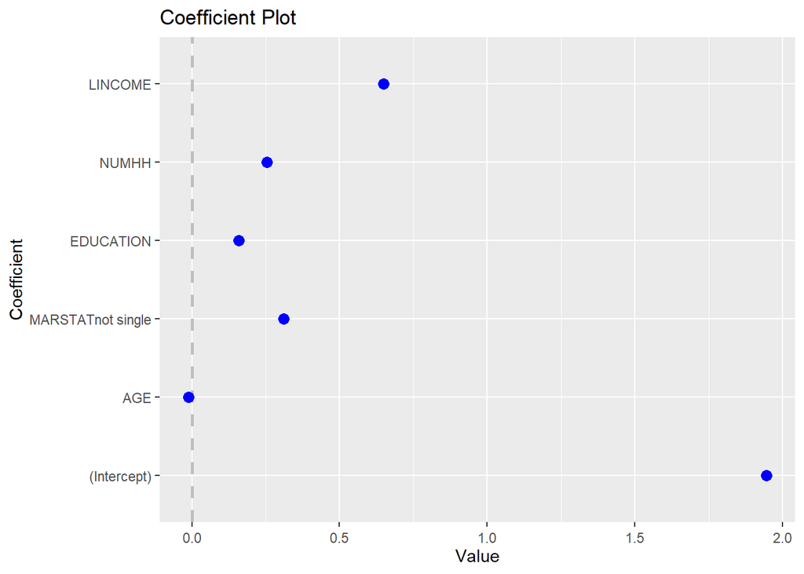

```r
modLasso = glmnet(x = makeX(tl[train,names(tl)!= "LFACE"]),
                  y = tl$LFACE[train],
                  alpha = 1,
                  lambda = cvModLasso$lambda.min,
                  standardize = TRUE,
                  family = "gaussian")
coefplot(modLasso)
```

```r
coef.glmnet(modLasso, s = cvModLasso$lambda.min)
```

```
## 7 x 1 sparse Matrix of class "dgCMatrix"
##                            s1
## (Intercept)        1.94394349
## AGE               -0.01146647
## MARSTATnot single  0.30992159
## MARSTATsingle      .
## EDUCATION          0.15876524
## NUMHH              0.25386762
## LINCOME            0.64806305
```

#### Ridge

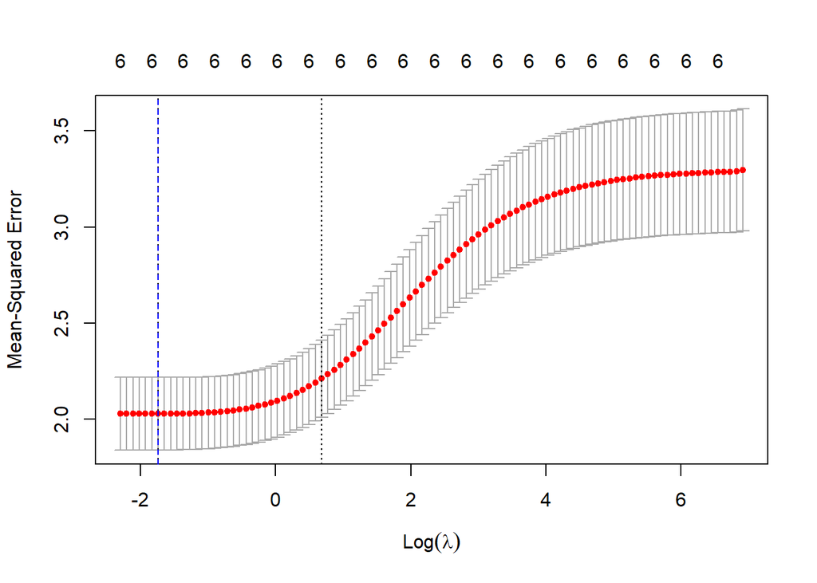

```r
modRidge = glmnet(x = makeX(tl[train,names(tl)!= "LFACE"]),
                  y = tl$LFACE[train],
                  alpha = 0)
cvModRidge = cv.glmnet(makeX(tl[train,names(tl)!= "LFACE"]),
                       tl$LFACE[train],
                       alpha = 0)
{
  plot(cvModRidge)
  abline(v = log(cvModRidge$lambda.min), col = "blue", lty = 2)
}
```

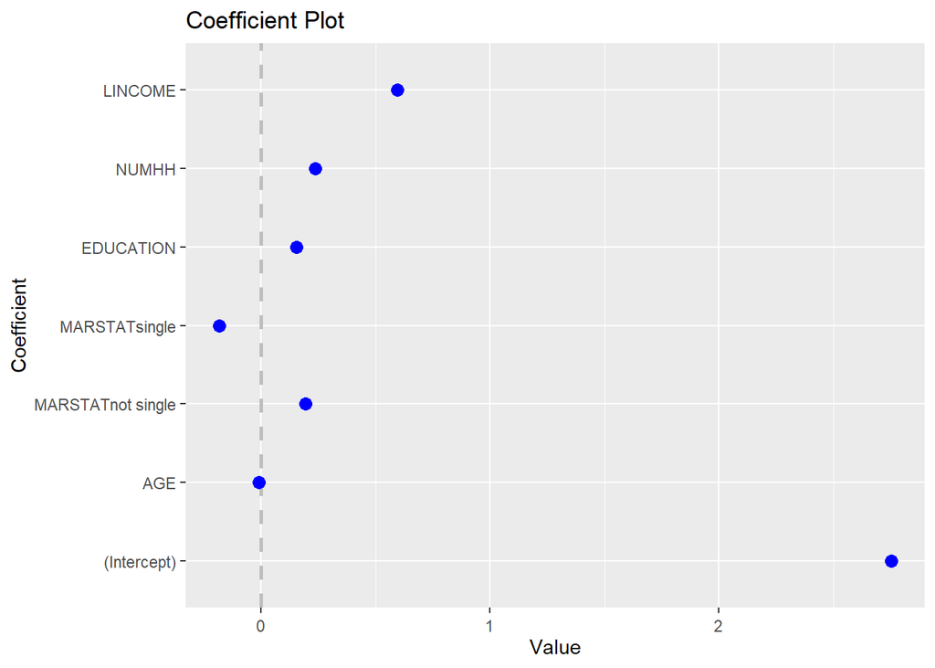

```r
modRidge = glmnet(x = makeX(tl[train,names(tl)!= "LFACE"]),
                  y = tl$LFACE[train],
                  alpha = 0,
                  lambda = cvModRidge$lambda.min,
                  standardize = TRUE,
                  family = "gaussian")
coefplot(modRidge)
```

### Confronto modelli

Come deducibile la variabile `LINCOME` è la più influente su tutti gli modelli. Interessante notare come i modelli ridge e lasso contengano la variabile `MARSTAT` mentre il modello di regressione lineare no, oltretutto il coefficiente è elvato ma giustificatodal fatto che la variabile può assumere solo valori 0 e 1.

## Potatura

Produco un albero di regressione e stampo il grafico delle variabili più influenti nel modello.

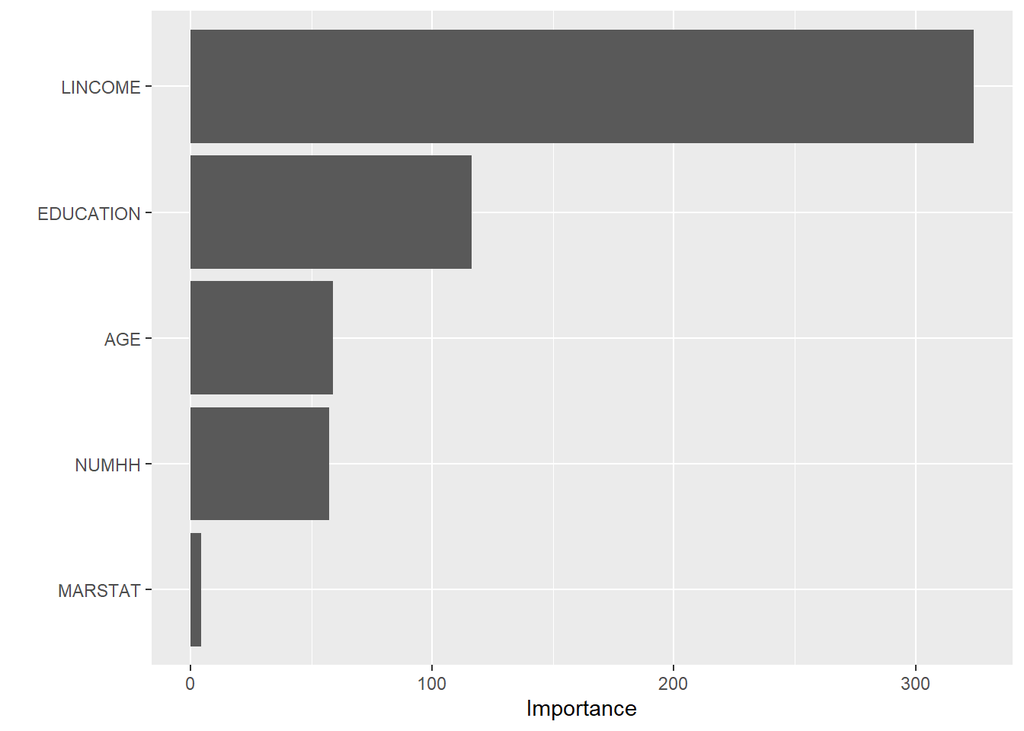

```r
alberoRpart = rpart::rpart(LFACE ~ .,
                      data = tl,
                      subset = train,
                      method = "anova",
                      control = rpart.control(minsplit = 10, cp = 0.003))
vip::vip(alberoRpart)
```

Di seguito viene raffigurato il grafico ad albero con un elevato numero di nodi. Successivamente è presente un grafico rappresentate l’errore relativo dell’albero al variare del cp (*cost complexity pruning*) e si noti come inizialmente la curva decresce per poi tornare a crescere.

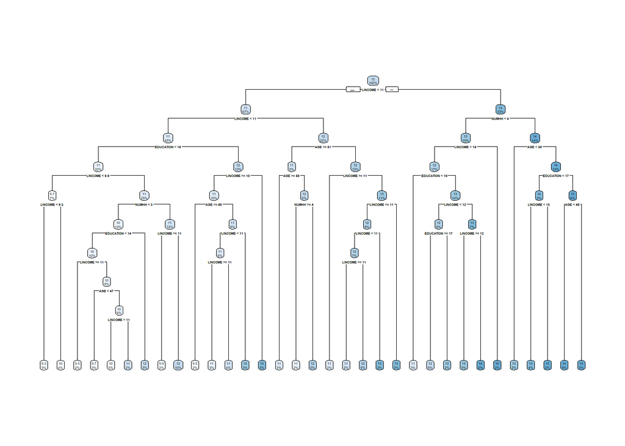

```r
rpart.plot(alberoRpart)
```

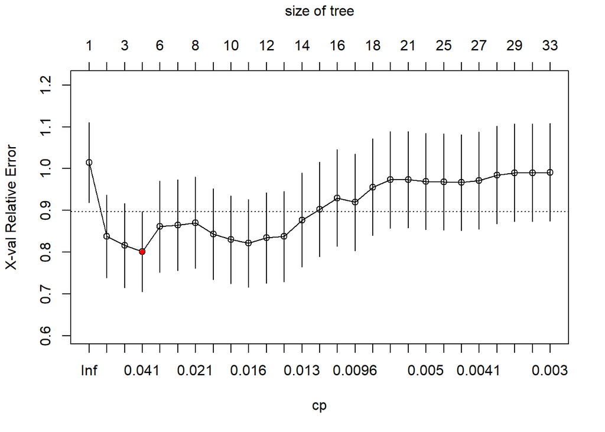

```r
{
  plotcp(alberoRpart)
  points(x = which.min(alberoRpart$cptable[,"xerror"]),
         y = min(alberoRpart$cptable[,"xerror"]),
         col = "red",
         pch = 18)
}
```

Il cp ottimale risulta essere 0.025. Stampo, allora, il nuovo albero potato. In questo caso l’albero avrà solamente 4 nodi foglia e verranno utilizzate 2 variabili.

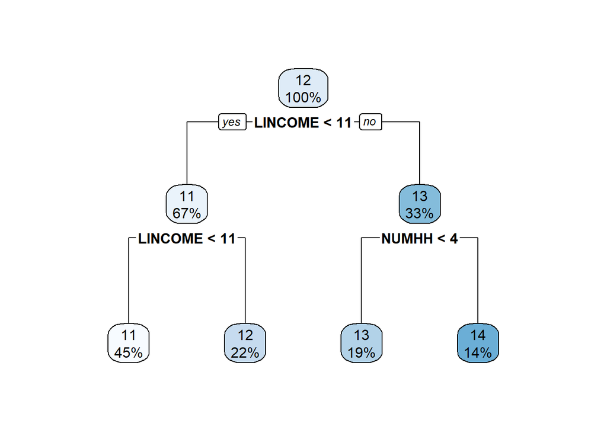

```r
rpart.plot(rpart(LFACE ~ .,
                      data = tl,
                      subset = train,
                      method = "anova",
                      control = rpart.control(cp = alberoRpart$cptable[which.min(alberoRpart$cptable[,"xerror"]),"CP"])))
```

### Potatura tramite cross-validation

Ora eseguo la stessa operazione ma utilizzando la cross-validation come metodo per potare l’albero.

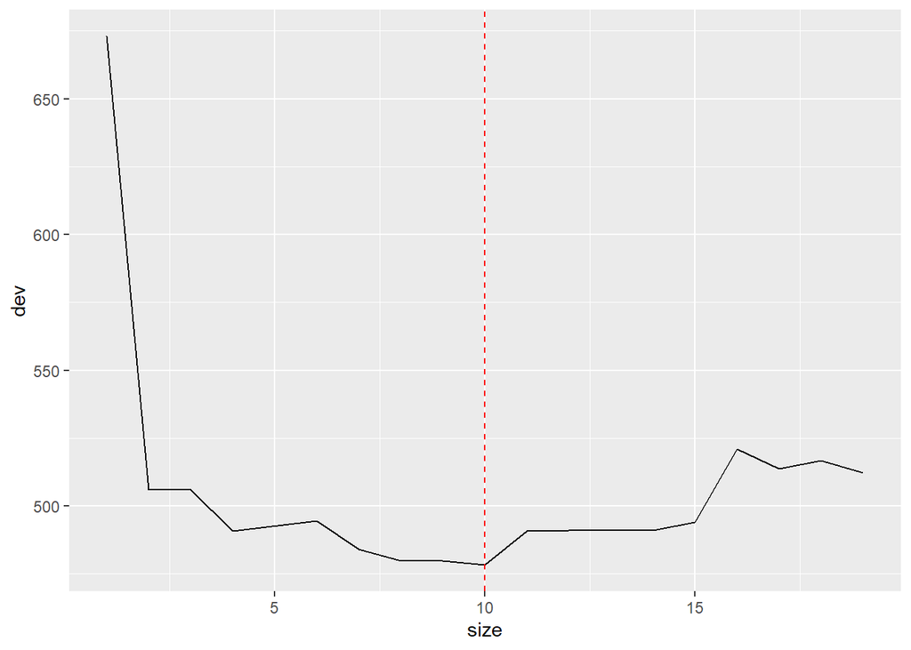

```r
set.seed(1)
alberoTree = tree(LFACE ~ .,
                  data = tl,
                  subset = train,
                  control = tree.control(nobs = length(train),
                                         minsize = 5))

cvAlbero = cv.tree(alberoTree)

cv = data.frame(size = cvAlbero$size, dev = cvAlbero$dev)

ggplot(cv, mapping = aes(x = size,y = dev), size = 10) +
  geom_line() +
  geom_vline(mapping = aes(xintercept = which.min(dev)), color = "red", linetype = 2)
```

L’albero migliore risulta essere quello con 10 nodi terminali.

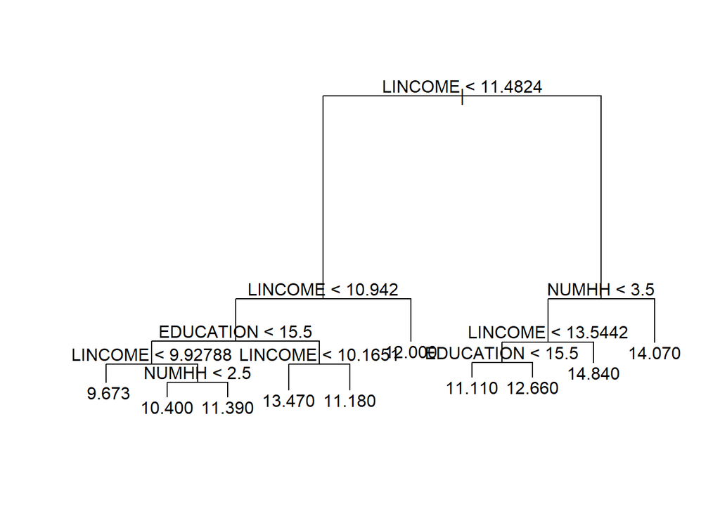

```r
alberoPotato = prune.tree(alberoTree, best = which.min(cv$dev))

{
  plot(alberoPotato)
  text(alberoPotato)
}
```

## MSE

```r
set.seed(1)

calcolaMSE = function(nodiFinali, dati, varDipendente, subsTrain, subsTest)
{
  t = prune.tree(tree(get(varDipendente) ~ .,
                      data = dati,
                      subset = subsTrain,
                      control = tree.control(nobs = length(subsTrain),minsize = nodiFinali)),
                 best = nodiFinali)
  return(sqrt(mean((unlist(dati[subsTest,colnames(dati) == varDipendente] - predict(t,newdata = dati[subsTest,])))^2)))
}

mseTrain = sapply(c(2:10), function(X) calcolaMSE(X,dati = tl,varDipendente = "LFACE",subsTrain = train, subsTest = train))
mseTest = sapply(c(2:10), function(X) calcolaMSE(X,dati = tl,varDipendente = "LFACE",subsTrain = c(1:length(tl$AGE))[-train], subsTest = c(1:length(tl$AGE))[-train]))
mseCV = sapply(c(2:10), function(X) calcolaMSE(X,dati = tl,varDipendente = "LFACE",subsTrain = c(1:length(tl$AGE))[train], subsTest = c(1:length(tl$AGE))[-train]))
```

Nel grafico seguente sono rappresentati gli errori quadratici medi sugli alberi con diversi nodi e diversi dati. La curva *train* corrisponde ai modelli addestrati sui dati train e validati con i medesimi dati, infatti è la curva con l’MSE minore delle altre. La curva *test*, invece, corrisponde ai modelli addesstrati sui dati test e validati con i medesimi dati, questa curva è molto simile alla precedente ma tende a essere maggiore in alcuni punti in quanto la dimensione del dataset test è minore di quella del dataset train. La curva *CV*, corrisponde ai modelli addestrati con i dati train ma validati sui dati test, essa risulta essere la più alta ma anche la più veritiera (meno distorta).

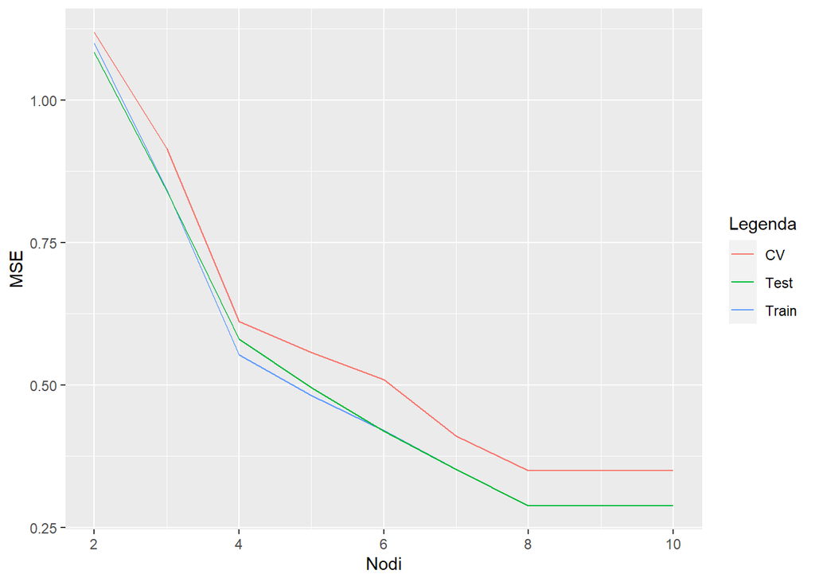

```r
df = tibble(nodi = c(2:10),mseTrain,mseTest,mseCV) %>% na.omit()

ggplot(df,mapping = aes(x = nodi)) +
  geom_line(aes(y = mseTrain,
                color = "Train")) +
  geom_line(aes(y = mseTest,
                color = "Test")) +
  geom_line(aes(y = mseCV,
                color = "CV")) +
  labs(y = "MSE", x = "Nodi",color = "Legenda")
```

## MARS

Stimo un primo modello MARS.

```r
modMars = earth(LFACE ~ ., data = tl, nprune = 7, degree = 1)
modMars %>% summary
```

```
## Call: earth(formula=LFACE~., data=tl, degree=1, nprune=7)
##
##                    coefficients
## (Intercept)          11.5522454
## h(EDUCATION-14)      -1.6308494
## h(EDUCATION-15)       4.1403612
## h(EDUCATION-16)      -2.4230637
## h(4-NUMHH)           -0.4417816
## h(LINCOME-10.6919)    0.7900094
##
## Selected 6 of 15 terms, and 3 of 5 predictors (nprune=7)
## Termination condition: Reached nk 21
## Importance: LINCOME, NUMHH, EDUCATION, AGE-unused, MARSTATsingle-unused
## Number of terms at each degree of interaction: 1 5 (additive model)
## GCV 2.194151    RSS 556.0856    GRSq 0.3753119    RSq 0.4200775
```

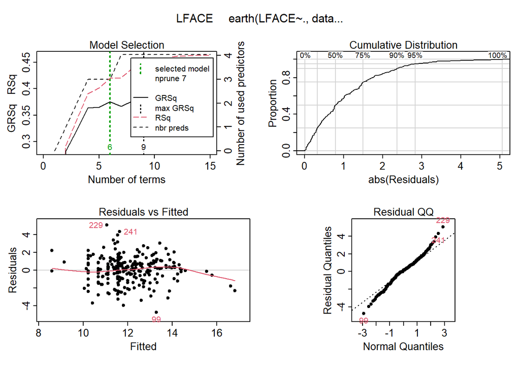

```r
plot(modMars)
```

```r
gradi = which.max(sapply(c(1:5), function(d) earth(LFACE ~ ., data = tl, nprune = 7, degree = d) %>% summary %>% .$rsq))
modMars = earth(LFACE ~ ., data = tl, nprune = 7, degree = gradi)
modMars %>% summary
```

```
## Call: earth(formula=LFACE~., data=tl, degree=gradi, nprune=7)
##
##                                      coefficients
## (Intercept)                            10.7741142
## h(EDUCATION-15)                         2.8382491
## h(EDUCATION-16)                        -1.8479160
## h(4-NUMHH)                             -0.4034998
## h(LINCOME-10.1266)                      1.3528800
## h(EDUCATION-14) * h(LINCOME-9.39266)   -0.7683679
## h(EDUCATION-15) * h(LINCOME-10.7144)    0.8783589
##
## Selected 7 of 19 terms, and 3 of 5 predictors (nprune=7)
## Termination condition: Reached nk 21
## Importance: LINCOME, NUMHH, EDUCATION, AGE-unused, MARSTATsingle-unused
## Number of terms at each degree of interaction: 1 4 2
## GCV 2.130717    RSS 519.7476    GRSq 0.393372    RSq 0.4579731
```

La variabile `AGE` non viene utilzzita, mentre vengono considerate alcune interazioni tra le variabili `EDUCATION` e `LINCOME`.

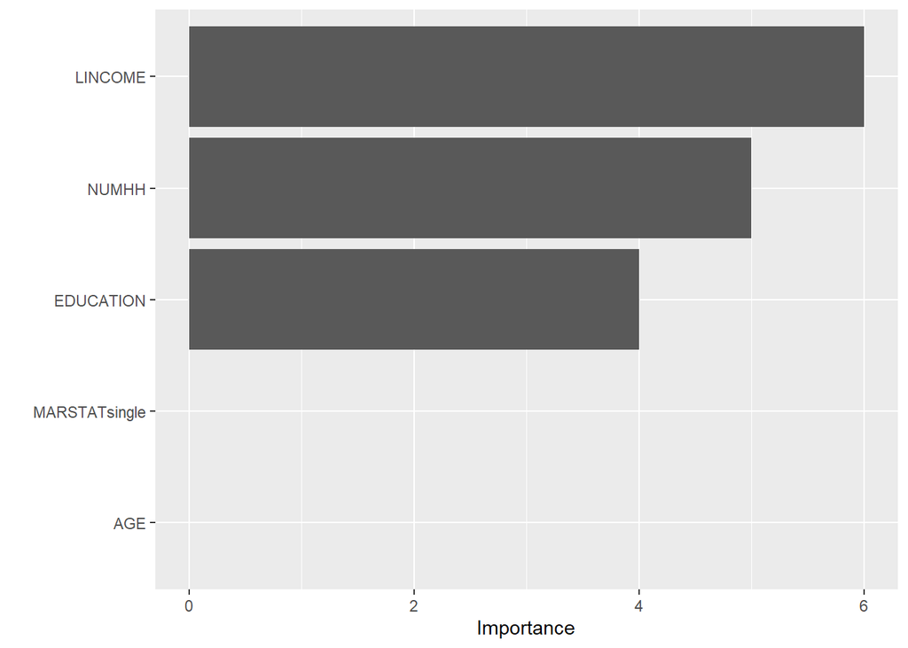

```r
vip::vip(modMars)
```